# Report

Report

```python
import os
import time
import pandas as pd
import numpy as np
import matplotlib.pyplot as plt
import random
from collections import Counter
import Search_H
import A_Star_MST
import Local_Search
```

Preparing Data and Defining Functions

```python
def read_matrix(lines):
    data = []
    for line in lines:
        row = list(map(float, line.strip().split()))
        data.append(row)
    return pd.DataFrame(data)
```

```python
# retrieves matricies from file
path = '/home/sawbyrd/CMSC421/revised_square_graph_5_10_..._50_/square_graph/'

# Initialize a dictionary to hold the arrays for each size
groups = {
    5: [],
    10: [],
    15: [],
    20: [],
    25: [],
    30: [],
    35: [],
    40: [],
    45: [],
    50: []
}

# Iterate through each file in the directory
for filename in os.listdir(path):
    # Check if the file is a text file
    if filename.endswith('.txt'):
        size = int(filename.split('_')[2])  # Extract size from filename

        # Read the contents of the file
        with open(os.path.join(path, filename), 'r') as file:
            n = file.readline()
            lines = file.readlines()
            matrix = read_matrix(lines)

        # Append the content to the corresponding size group
        if size in groups:
            groups[size].append(matrix)

for size, docs in groups.items():
    print(f"Size {size} has {len(docs)} documents.")
```

```
Size 5 has 30 documents.
Size 10 has 30 documents.
Size 15 has 30 documents.
Size 20 has 30 documents.
Size 25 has 30 documents.
Size 30 has 30 documents.
Size 35 has 30 documents.
Size 40 has 30 documents.
Size 45 has 30 documents.
Size 50 has 30 documents.
```

```python
sizes = [5, 10, 15, 20, 25, 30, 35, 40]

families_f = []

for size in sizes:
    families_f.append(groups[size])
```

```python
# creates a 'number' of random matricies (as dataframes) of size 'size'
def rand_matrix(size, number):
    matricies = []
    for _ in range(0, number):
        matrix = np.random.randint(1, 1000, size=(size, size))
        symmetric_matrix = np.triu(matrix) + np.triu(matrix, 1).T
        np.fill_diagonal(symmetric_matrix, 0)
        df = pd.DataFrame(symmetric_matrix)
        matricies.append(df)
    return matricies
```

```python
# an example of this working
matricies = rand_matrix(5, 3)
for matrix in matricies:
    print(matrix, '\n')
```

```
     0    1    2    3    4
0    0  658  426  173  710
1  658    0   44  727  125
2  426   44    0  484  285
3  173  727  484    0  614
4  710  125  285  614    0

     0    1    2    3    4
0    0  773  820  324  305
1  773    0  320  603  559
2  820  320    0  781  666
3  324  603  781    0  412
4  305  559  666  412    0

     0    1    2    3    4
0    0  552  903  311  163
1  552    0  344   41  693
2  903  344    0  423  676
3  311   41  423    0  757
4  163  693  676  757    0
```

```python
# creating a random family of matricies for len 5, 10, 15, and 20
families = []
families.append(rand_matrix(5, 30))
families.append(rand_matrix(10, 30))
families.append(rand_matrix(15, 30))
families.append(rand_matrix(20, 30))
families.append(rand_matrix(25, 30))
```

Search Hueristics

Before collecting data on Repeated Randomized NN2O, Testing different values of N to find best one

```python
# Initializing

for idx, temp in enumerate(families_f[:4], start=1):
    best_N_data = []

    for mat in temp:
        temp_m = temp[0]
        best_cost, exp, best_tour = Search_H.rrnn2o(mat, 1, 0)
        best_N = 1

        # testing different n
        for i in range(2, len(mat)):
            rrnn2o_cost, rrnn2o_exp, rrnn2o_tour = Search_H.rrnn2o(mat, i, 0)
            if rrnn2o_cost < best_cost:
                best_cost = rrnn2o_cost
                best_tour_t = rrnn2o_tour
                best_N = i

        best_N_data.append(best_N)

    # finding most occuring values and storing them
    ct_N = Counter(best_N_data)
    best_N, _ = ct_N.most_common(1)[0]
    print('--------------------')
    print('Best for size', idx*5)
    print('Best N: ', best_N)
```

```
--------------------
Best for size 5
Best N:  1
--------------------
Best for size 10
Best N:  1
--------------------
Best for size 15
Best N:  1
--------------------
Best for size 20
Best N:  1
```

The best N for RNN seems to always be 1

Running Algorithms

```python
graph_data = []

# Going through each family (size)
for i, family in enumerate(families_f, start=1):
    # initializing data collections
    nn_data = {
        'Cost': [],
        'Nodes Expanded': [],
        'CPU Runtime': [],
        'Real Runtime': []
    }

    nn2o_data = {
        'Cost': [],
        'Nodes Expanded': [],
        'CPU Runtime': [],
        'Real Runtime': []
    }

    rr_data = {
        'Cost': [],
        'Nodes Expanded': [],
        'CPU Runtime': [],
        'Real Runtime': []
    }

    # Going through each matrix in this family (size)
    for m in family:

        #*********************
        # Running Algorithms *
        #*********************

        # Running Nearest Neighbor
        nn_start_real = time.time()
        nn_start_CPU = time.process_time()
        nn_cost, nn_exp, nn_tour = Search_H.nearest_neighbor(m, 1, random.randint(0, len(m) - 1))
        nn_end_real = time.time()
        nn_end_CPU = time.process_time()

        # Running Nearest Neighbor 2-Opt
        nn2o_start_real = time.time()
        nn2o_start_CPU = time.process_time()
        nn2o_tour, nn2o_cost = Search_H.nn2o(nn_tour, m)
        nn2o_end_real = time.time()
        nn2o_end_CPU = time.process_time()

        # Running Repeated Randomized Nearest Neighbor With 2-Opt
        rr_start_real = time.time()
        rr_start_CPU = time.process_time()
        rr_cost, rr_exp, rr_tour = Search_H.rrnn2o(m, best_N, 0)
        rr_end_real = time.time()
        rr_end_CPU = time.process_time()

        #******************
        # Collecting Data *
        #******************

        # Nearest Neighbor
        nn_data['Cost'].append(nn_cost)
        nn_data['Nodes Expanded'].append(nn_exp)
        nn_data['CPU Runtime'].append(nn_end_CPU - nn_start_CPU)
        nn_data['Real Runtime'].append(nn_end_real - nn_start_real)

        # Nearest Neighbor 2-Opt
        nn2o_data['Cost'].append(nn2o_cost)
        nn2o_data['Nodes Expanded'].append(nn_exp)
            # Run time of nn2o is run time of 2-opt + runtime of NN
        nn2o_data['CPU Runtime'].append((nn2o_end_CPU - nn2o_start_CPU) + (nn_end_CPU - nn_start_CPU))
        nn2o_data['Real Runtime'].append((nn2o_end_real - nn2o_start_real) + (nn_end_real - nn_start_real))

        # Repeated Randomized Nearest Neighbor With 2-Opt
        rr_data['Cost'].append(rr_cost)
        rr_data['Nodes Expanded'].append(rr_exp)
        rr_data['CPU Runtime'].append(rr_end_CPU - rr_start_CPU)
        rr_data['Real Runtime'].append(rr_end_real - rr_start_real)

    #*****************
    # Compiling Data *
    #*****************

    # NN
    nn_df = pd.DataFrame(nn_data)
    nn_averages = nn_df.mean()
    nn_min = nn_df.min()
    nn_max = nn_df.max()

    # NN2O
    nn2o_df = pd.DataFrame(nn2o_data)
    nn2o_averages = nn2o_df.mean()
    nn2o_min = nn2o_df.min()
    nn2o_max = nn2o_df.max()

    # RRNN2O
    rr_df = pd.DataFrame(rr_data)
    rr_averages = rr_df.mean()
    rr_min = rr_df.min()
    rr_max = rr_df.max()

    # GRAPH DATA
    graph_data.append({
        'NN': nn_averages,
        'NN2O': nn2o_averages,
        'RNN': rr_averages
    })

    # Combining
    combined_avg = pd.concat([nn_averages, nn2o_averages, rr_averages], axis=1)
    combined_avg.columns = ['NN', 'NN2O', 'RNN']

    combined_min = pd.concat([nn_min, nn2o_min, rr_min], axis=1)
    combined_min.columns = ['NN', 'NN2O', 'RNN']

    combined_max = pd.concat([nn_max, nn2o_max, rr_max], axis=1)
    combined_max.columns = ['NN', 'NN2O', 'RNN']

    # Printing Results
    print('------------------------------')
    print('| AVERAGE/MIN/MAX For Size', i*5, '|')
    print('------------------------------')
    print('| By Algorithm |')
    print('----------------')
    print('Averages: \n', combined_avg, '\n')
    print('Minimums: \n', combined_min, '\n')
    print('Maximums: \n', combined_max, '\n')
```

```
------------------------------
| AVERAGE/MIN/MAX For Size 5 |
------------------------------
| By Algorithm |
----------------
Averages:
                       NN      NN2O       RNN
Cost            4.058218  4.058218  4.000000
Nodes Expanded  4.000000  4.000000  4.000000
CPU Runtime     0.000074  0.000263  0.000075
Real Runtime    0.000073  0.000254  0.000074

Minimums:
                      NN      NN2O       RNN
Cost            4.00000  4.000000  4.000000
Nodes Expanded  4.00000  4.000000  4.000000
CPU Runtime     0.00005  0.000210  0.000063
Real Runtime    0.00005  0.000203  0.000063

Maximums:
                       NN      NN2O       RNN
Cost            4.847660  4.847660  4.000000
Nodes Expanded  4.000000  4.000000  4.000000
CPU Runtime     0.000434  0.000642  0.000136
Real Runtime    0.000384  0.000586  0.000135

------------------------------
| AVERAGE/MIN/MAX For Size 10 |
------------------------------
| By Algorithm |
----------------
Averages:
                       NN      NN2O       RNN
Cost            4.171809  4.171809  4.038380
Nodes Expanded  9.000000  9.000000  9.000000
CPU Runtime     0.000105  0.001134  0.000128
Real Runtime    0.000105  0.001126  0.000128

Minimums:
                       NN      NN2O       RNN
```

[output cut: 152 more lines]

```
Real Runtime     0.000486   0.099393   0.000596

Minimums:
                        NN       NN2O        RNN
Cost             3.999995   3.999995   3.999995
Nodes Expanded  39.000000  39.000000  39.000000
CPU Runtime      0.000453   0.083844   0.000525
Real Runtime     0.000453   0.083842   0.000524

Maximums:
                        NN       NN2O        RNN
Cost             4.571435   4.571434   4.842614
Nodes Expanded  39.000000  39.000000  39.000000
CPU Runtime      0.000623   0.251421   0.000720
Real Runtime     0.000622   0.251415   0.000719
```

Creating Graphs

```python
# Organizing data

sizes = [5, 10, 15, 20, 25, 30, 35, 40]

nn_avg = {
    'Cost': [series['NN']['Cost'] for series in graph_data],
    'Nodes': [series['NN']['Nodes Expanded'] for series in graph_data],
    'CPU': [series['NN']['CPU Runtime'] for series in graph_data],
    'Real': [series['NN']['Real Runtime'] for series in graph_data]
}

nn2o_avg = {
    'Cost': [series['NN2O']['Cost'] for series in graph_data],
    'Nodes': [series['NN2O']['Nodes Expanded'] for series in graph_data],
    'CPU': [series['NN2O']['CPU Runtime'] for series in graph_data],
    'Real': [series['NN2O']['Real Runtime'] for series in graph_data]
}

rnn_avg = {
    'Cost': [series['RNN']['Cost'] for series in graph_data],
    'Nodes': [series['RNN']['Nodes Expanded'] for series in graph_data],
    'CPU': [series['RNN']['CPU Runtime'] for series in graph_data],
    'Real': [series['RNN']['Real Runtime'] for series in graph_data]
}
```

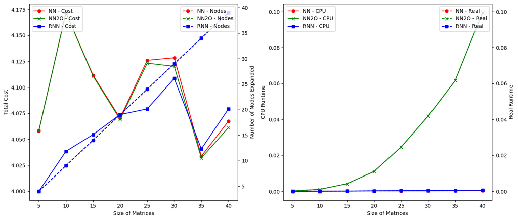

```python
# creating axis/plots
fig, (ax1, ax2) = plt.subplots(1, 2, figsize=(14, 6))

# First Graph
# First Axis (Cost)
ax1.plot(sizes, nn_avg['Cost'], label='NN - Cost', color='r', marker='o')
ax1.plot(sizes, nn2o_avg['Cost'], label='NN2O - Cost', color='g', marker='x')
ax1.plot(sizes, rnn_avg['Cost'], label='RNN - Cost', color='b', marker='s')
ax1.set_xlabel('Size of Matrices')
ax1.set_ylabel('Total Cost')

# Second Axis (Number of Nodes Expanded)
ax1_2 = ax1.twinx()
ax1_2.plot(sizes, nn_avg['Nodes'], label='NN - Nodes', color='r', marker='o', linestyle='--')
ax1_2.plot(sizes, nn2o_avg['Nodes'], label='NN2O - Nodes', color='g', marker='x', linestyle='--')
ax1_2.plot(sizes, rnn_avg['Nodes'], label='RNN - Nodes', color='b', marker='s', linestyle='--')
ax1_2.set_ylabel('Number of Nodes Expanded')

# Legends for both y-axes
ax1.legend(loc='upper left')
ax1_2.legend(loc='upper right')


# Second Graph
# First Axis (CPU Runtime)
ax2.plot(sizes, nn_avg['CPU'], label='NN - CPU', color='r', marker='o')
ax2.plot(sizes, nn2o_avg['CPU'], label='NN2O - CPU', color='g', marker='x')
ax2.plot(sizes, rnn_avg['CPU'], label='RNN - CPU', color='b', marker='s')
ax2.set_xlabel('Size of Matrices')
ax2.set_ylabel('CPU Runtime')

# Second Axis (Real Runtime)
ax2_2 = ax2.twinx()
ax2_2.plot(sizes, nn_avg['Real'], label='NN - Real', color='r', marker='o', linestyle='--')
ax2_2.plot(sizes, nn2o_avg['Real'], label='NN2O - Real', color='g', marker='x', linestyle='--')
ax2_2.plot(sizes, rnn_avg['Real'], label='RNN - Real', color='b', marker='s', linestyle='--')
ax2_2.set_ylabel('Real Runtime')

# Legends for both y-axes
ax2.legend(loc='upper left')
ax2_2.legend(loc='upper right')

# Display the plots
plt.tight_layout()
plt.show()
```

Another observation can be made about the number of nodes expanded. All three algorithms seem to follow the same linear increase in the number of nodes expanded. In fact, by checking the data that I printed out, the number of nodes is exactly the same across the three. They also increase by the same amount each time, 5x+4

When it comes to runtimes, the time complexity of NN2O increases much faster (exponentially) with the size of the graph than the other two algorithms. This is due to the fact that it has to loop through each row and column -> N^2, on top of running NN first.

RNN calls NN2O after each iteration so you would immagine that it's runtime and nodes expanded would be greater than that of NN2O. However since the amount of restarts is 0, it only does this once and there are unlikely to be many optimizations to be made.

A* With MST

```python
A_avg_cost = []
A_avg_nodes = []

# only using up to size 15 because it takes to long after that
for i, family in enumerate(families_f[:3], start=1):

    # initializing data collections
    A_data = {
        'Cost': [],
        'Nodes Expanded': [],
        'Real Runtime': []
    }

    # Going through each matrix in this family (size)
    for m in family:

        #********************
        # Running Algorithm *
        #********************

        # Running A* With MST
        A_start_real = time.time()
        A_cost, A_tour, exp = A_Star_MST.a_star(m)
        A_end_real = time.time()

        #******************
        # Collecting Data *
        #******************

        # A* With MST
        A_data['Cost'].append(A_cost)
        A_data['Nodes Expanded'].append(exp)
        A_data['Real Runtime'].append(A_end_real - A_start_real)

    #*****************
    # Compiling Data *
    #*****************

    # A*
    A_df = pd.DataFrame(A_data)
    A_averages = A_df.mean()
    A_min = A_df.min()
    A_max = A_df.max()

    A_avg_cost.append(A_averages['Cost'])
    A_avg_nodes.append(A_averages['Nodes Expanded'])

    # Printing Results
    print('------------------------------')
    print('| AVERAGE/MIN/MAX For Size', i*5, '|')
    print('------------------------------')
    print('Averages: \n', A_averages, '\n')
    print('Minimums: \n', A_min, '\n')
    print('Maximums: \n', A_max, '\n')
```

```
------------------------------
| AVERAGE/MIN/MAX For Size 5 |
------------------------------
Averages:
 Cost               4.000000
Nodes Expanded    37.533333
Real Runtime       0.007918
dtype: float64

Minimums:
 Cost               4.000000
Nodes Expanded    36.000000
Real Runtime       0.006943
dtype: float64

Maximums:
 Cost               4.000000
Nodes Expanded    39.000000
Real Runtime       0.017278
dtype: float64

------------------------------
| AVERAGE/MIN/MAX For Size 10 |
------------------------------
Averages:
 Cost                 4.000000
Nodes Expanded    1106.266667
Real Runtime         0.265133
dtype: float64

Minimums:
 Cost                3.999999
Nodes Expanded    400.000000
Real Runtime        0.097107
dtype: float64

Maximums:
 Cost                 4.000001
Nodes Expanded    3941.000000
Real Runtime         0.999799
dtype: float64

------------------------------
| AVERAGE/MIN/MAX For Size 15 |
------------------------------
Averages:
 Cost                  4.000000
Nodes Expanded    15774.866667
Real Runtime          3.931560
dtype: float64

Minimums:
 Cost                 3.999998
Nodes Expanded    1188.000000
Real Runtime         0.298457
dtype: float64

Maximums:
 Cost                   4.000002
Nodes Expanded    147450.000000
Real Runtime          36.941355
dtype: float64
```

Making Graphs

Computing average difference of cost and nodes expanded between A* and each search heuristic algorithm.

```python
# The average difference for each matrix = the difference of averages for each matrix.
# Only including the data from graph sizes 5 - 15 because 20 took too long for A*

cost_differences = {
    'NN vs A': [cost - A_avg_cost[i] for i, cost in enumerate(nn_avg['Cost'][:3])],
    'NN2O vs A': [cost - A_avg_cost[i] for i, cost in enumerate(nn2o_avg['Cost'][:3])],
    'RNN vs A': [cost - A_avg_cost[i] for i, cost in enumerate(rnn_avg['Cost'][:3])]
}

exp_differences = {
    'NN vs A': [A_avg_nodes[i] - expanded for i, expanded in enumerate(nn_avg['Nodes'][:3])],
    'NN2O vs A': [A_avg_nodes[i] - expanded for i, expanded in enumerate(nn2o_avg['Nodes'][:3])],
    'RNN vs A': [A_avg_nodes[i] - expanded for i, expanded in enumerate(rnn_avg['Nodes'][:3])]
}

graph_sizes = [5, 10, 15]
```

Ploting Cost vs Size

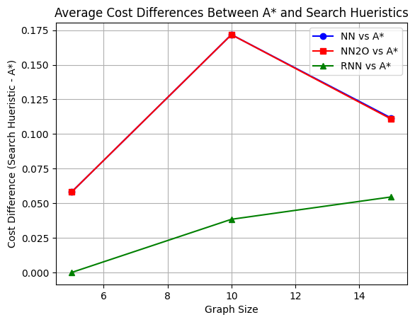

```python
# Plot the cost differences for each algorithm comparison
plt.plot(graph_sizes, cost_differences['NN vs A'], label='NN vs A*', marker='o', color='blue')
plt.plot(graph_sizes, cost_differences['NN2O vs A'], label='NN2O vs A*', marker='s', color='red')
plt.plot(graph_sizes, cost_differences['RNN vs A'], label='RNN vs A*', marker='^', color='green')

# Add labels for x and y axes
plt.xlabel('Graph Size')
plt.ylabel('Cost Difference (Search Hueristic - A*)')

# Add title to the plot
plt.title('Average Cost Differences Between A* and Search Hueristics')

# Add a legend to differentiate between the lines
plt.legend()

# Optionally, add gridlines for better readability
plt.grid(True)

# Show the plot
plt.show()
```

A* always finds the optimal solution so this graph could also represent the distance of the other three algorithms from the optimal solution. I have a pretty beefy computer and A* still took a longggggg time on any graph bigger than 15 nodes, but I wish I could compare the graphs of size 20, 25, etc. to see if there are any other trends as the size increases.

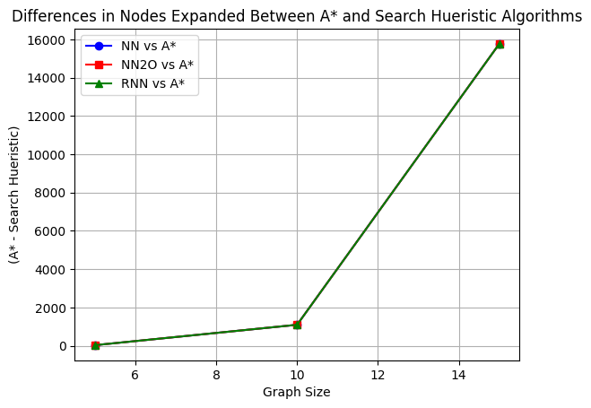

```python
# Plot the cost differences for each algorithm comparison
plt.plot(graph_sizes, exp_differences['NN vs A'], label='NN vs A*', marker='o', color='blue')
plt.plot(graph_sizes, exp_differences['NN2O vs A'], label='NN2O vs A*', marker='s', color='red')
plt.plot(graph_sizes, exp_differences['RNN vs A'], label='RNN vs A*', marker='^', color='green')

# Add labels for x and y axes
plt.xlabel('Graph Size')
plt.ylabel('(A* - Search Hueristic)')

# Add title to the plot
plt.title('Differences in Nodes Expanded Between A* and Search Hueristic Algorithms')

# Add a legend to differentiate between the lines
plt.legend()

# Optionally, add gridlines for better readability
plt.grid(True)

# Show the plot
plt.show()
```

Local Search Algorithms

Hill Climb

```python
# Testing different values of r (number of restarts)

for idx, temp in enumerate(families_f[:4], start=1):
    best_r_data = []

    for mat in temp:

        best_tour, best_cost, exp = Local_Search.rrhc(mat, 1)
        best_r = 1

        # testing different r
        # only going up to 5 because any more will take too long for larger graphs
        for i in range(2, 5):
            rrhc_tour, rrhc_cost, rrhc_exp = Local_Search.rrhc(mat, i)
            # if the cost is better, new best is w/ r = i
            if rrhc_cost < best_cost:
                best_cost = rrhc_cost
                best_tour = rrhc_tour
                best_r = i

        best_r_data.append(best_r)

    # finding most occuring values and storing them
    ct_r = Counter(best_r_data)
    best_r, _ = ct_r.most_common(1)[0]
    print('--------------------------------------')
    print('Best Number of Restarts for Size', idx*5)
    print('Best Values and their Counts: \n', ct_r)
    print('Best R: ', best_r)
```

```
--------------------------------------
Best Number of Restarts for Size 5
Best Values and their Counts:
 Counter({1: 29, 3: 1})
Best R:  1
--------------------------------------
Best Number of Restarts for Size 10
Best Values and their Counts:
 Counter({2: 11, 3: 8, 1: 7, 4: 4})
Best R:  2
--------------------------------------
Best Number of Restarts for Size 15
Best Values and their Counts:
 Counter({4: 14, 3: 6, 1: 5, 2: 5})
Best R:  4
--------------------------------------
Best Number of Restarts for Size 20
Best Values and their Counts:
 Counter({4: 14, 3: 8, 2: 5, 1: 3})
Best R:  4
```

Every time I do the test above, something different happens. This is probably due to the randomness involved. However, logically it is safe to say that more restarts increase the likelyhood of finding an optimal or just better solution. This is especially true for larger graphs but also takes much longer for larger graphs.

I debated weather or not to use the number of nodes as the number of restarts but it just took too long for the larger graphs. So for now I will be sticking with the minimum of the length of the matrix and 10

Running Algorithm and Collecting Data

```python
HC_avg_cost = []
HC_avg_cpu = []

# only using up to size 15 because it takes to long after that
for i, family in enumerate(families_f[:4], start=1):

    # initializing data collections
    HC_data = {
        'Cost': [],
        'Nodes Expanded': [],
        'Real Runtime': [],
        'CPU Runtime': []
    }

    # Going through each matrix in this family (size)
    for m in family:

        #********************
        # Running Algorithm *
        #********************

        # Running Hill Climb
        HC_start_real = time.time()
        HC_start_CPU = time.process_time()
        HC_tour, HC_cost, HC_exp = Local_Search.rrhc(m, min(len(m), 10))
        HC_end_real = time.time()
        HC_end_CPU = time.process_time()

        #******************
        # Collecting Data *
        #******************

        # Hill Climb
        HC_data['Cost'].append(HC_cost)
        HC_data['Nodes Expanded'].append(HC_exp)
        HC_data['Real Runtime'].append(HC_end_real - HC_start_real)
        HC_data['CPU Runtime'].append(HC_end_CPU - HC_start_CPU)

    #*****************
    # Compiling Data *
    #*****************

    # HC
    HC_df = pd.DataFrame(HC_data)
    HC_averages = HC_df.mean()
    HC_min = HC_df.min()
    HC_max = HC_df.max()

    HC_avg_cost.append(HC_averages['Cost'])
    HC_avg_cpu.append(HC_averages['CPU Runtime'])

    # Printing Results
    print('------------------------------')
    print('| AVERAGE/MIN/MAX For Size', i*5, '|')
    print('------------------------------')
    print('Averages: \n', HC_averages, '\n')
    print('Minimums: \n', HC_min, '\n')
    print('Maximums: \n', HC_max, '\n')
```

```
------------------------------
| AVERAGE/MIN/MAX For Size 5 |
------------------------------
Averages:
 Cost               4.000000
Nodes Expanded    77.200000
Real Runtime       0.003913
CPU Runtime        0.003951
dtype: float64

Minimums:
 Cost               4.000000
Nodes Expanded    54.000000
Real Runtime       0.002568
CPU Runtime        0.002569
dtype: float64

Maximums:
 Cost                4.000000
Nodes Expanded    108.000000
Real Runtime        0.005695
CPU Runtime         0.005780
dtype: float64

------------------------------
| AVERAGE/MIN/MAX For Size 10 |
------------------------------
Averages:
 Cost                 4.001908
Nodes Expanded    2073.600000
Real Runtime         0.169076
CPU Runtime          0.169089
dtype: float64

Minimums:
 Cost                 3.999999
Nodes Expanded    1692.000000
Real Runtime         0.139658
CPU Runtime          0.139663
dtype: float64
```

[output cut: 40 more lines]

```
dtype: float64

Minimums:
 Cost                  3.999999
Nodes Expanded    18810.000000
Real Runtime          2.878388
CPU Runtime           2.878446
dtype: float64

Maximums:
 Cost                  6.722612
Nodes Expanded    27873.000000
Real Runtime          4.246112
CPU Runtime           4.246182
dtype: float64
```

Making Graphs

```python
# The average difference for each matrix = the difference of averages for each matrix.
# Since A* with graph size 20 took too long, I just added the difference between HC and 4.0
# to the end because A* always finds the optimal solution (4.0)

HC_cost_diff = {
    'NN vs HC': [HC_avg_cost[i] - cost for i, cost in enumerate(nn_avg['Cost'][:4])],
    'NN2O vs HC': [HC_avg_cost[i] - cost for i, cost in enumerate(nn2o_avg['Cost'][:4])],
    'RNN vs HC': [HC_avg_cost[i] - cost for i, cost in enumerate(rnn_avg['Cost'][:4])],
    'A* vs HC': [HC_avg_cost[i] - cost for i, cost in enumerate(A_avg_cost)] + [HC_avg_cost[3] - 4.0]
}
```

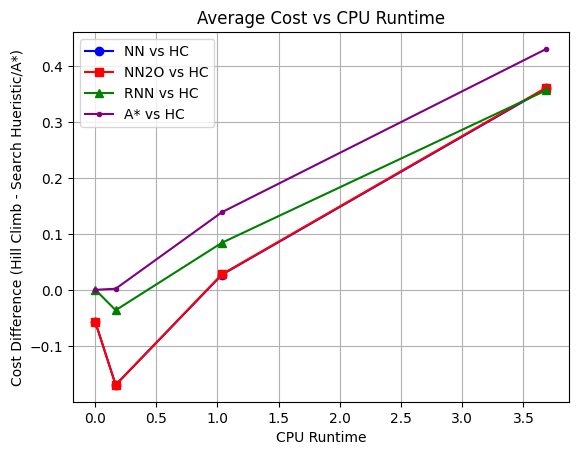

```python
plt.plot(HC_avg_cpu, HC_cost_diff['NN vs HC'], label='NN vs HC', marker='o', color='blue')
plt.plot(HC_avg_cpu, HC_cost_diff['NN2O vs HC'], label='NN2O vs HC', marker='s', color='red')
plt.plot(HC_avg_cpu, HC_cost_diff['RNN vs HC'], label='RNN vs HC', marker='^', color='green')
plt.plot(HC_avg_cpu, HC_cost_diff['A* vs HC'], label='A* vs HC', marker='.', color='purple')

# Add labels for x and y axes
plt.xlabel('CPU Runtime')
plt.ylabel('Cost Difference (Hill Climb - Search Hueristic/A*)')

# Add title to the plot
plt.title('Average Cost vs CPU Runtime')

# Add a legend to differentiate between the lines
plt.legend()

# Optionally, add gridlines for better readability
plt.grid(True)

# Show the plot
plt.show()
```

When using the Hill Climb Algorithm, I quickly noticed that withought restarting with a randome initial path, the solutions were pretty bad. After using the random restarts, the solutions got much better.

However, the as the graph size increases, if you want to find the optimal solution then the number of restarts must increase as well. since I have kept the number of restarts at a semi-static number (5 or 10) the 3rd and 4th size of graphs (15 and 20 nodes) took a long time and was significantly worse.

Simulated Annealing

```python
SA_avg_cost = []
SA_avg_cpu = []

# only using up to size 15 because it takes to long after that
for i, family in enumerate(families_f[:4], start=1):

    # initializing data collections
    SA_data = {
        'Cost': [],
        'Nodes Expanded': [],
        'Real Runtime': [],
        'CPU Runtime': []
    }

    # Going through each matrix in this family (size)
    for m in family:

        #********************
        # Running Algorithm *
        #********************

        # Running Simulated Annealing
        SA_start_real = time.time()
        SA_start_CPU = time.process_time()
        SA_tour, SA_cost, SA_exp = Local_Search.rrsa(m, 100, 0.001, 0.99, 8)
        SA_end_real = time.time()
        SA_end_CPU = time.process_time()

        #******************
        # Collecting Data *
        #******************

        # SA
        SA_data['Cost'].append(SA_cost)
        SA_data['Nodes Expanded'].append(SA_exp)
        SA_data['Real Runtime'].append(SA_end_real - SA_start_real)
        SA_data['CPU Runtime'].append(SA_end_CPU - SA_start_CPU)

    #*****************
    # Compiling Data *
    #*****************

    # SA
    SA_df = pd.DataFrame(SA_data)
    SA_averages = SA_df.mean()
    SA_min = SA_df.min()
    SA_max = SA_df.max()

    SA_avg_cost.append(SA_averages['Cost'])
    SA_avg_cpu.append(SA_averages['CPU Runtime'])

    # Printing Results
    print('------------------------------')
    print('| AVERAGE/MIN/MAX For Size', i*5, '|')
    print('------------------------------')
    print('Averages: \n', SA_averages, '\n')
    print('Minimums: \n', SA_min, '\n')
    print('Maximums: \n', SA_max, '\n')
```

```
------------------------------
| AVERAGE/MIN/MAX For Size 5 |
------------------------------
Averages:
 Cost                  4.000000
Nodes Expanded    55008.000000
Real Runtime          0.432520
CPU Runtime           0.432576
dtype: float64

Minimums:
 Cost                  4.000000
Nodes Expanded    55008.000000
Real Runtime          0.408080
CPU Runtime           0.408088
dtype: float64

Maximums:
 Cost                  4.000000
Nodes Expanded    55008.000000
Real Runtime          0.467723
CPU Runtime           0.467734
dtype: float64

------------------------------
| AVERAGE/MIN/MAX For Size 10 |
------------------------------
Averages:
 Cost                   4.000000
Nodes Expanded    330048.000000
Real Runtime           0.798504
CPU Runtime            0.798527
dtype: float64

Minimums:
 Cost                   3.999999
Nodes Expanded    330048.000000
Real Runtime           0.755507
CPU Runtime            0.755522
dtype: float64
```

[output cut: 40 more lines]

```
dtype: float64

Minimums:
 Cost              4.000000e+00
Nodes Expanded    1.567728e+06
Real Runtime      1.526283e+00
CPU Runtime       1.526308e+00
dtype: float64

Maximums:
 Cost              7.024550e+00
Nodes Expanded    1.567728e+06
Real Runtime      1.658746e+00
CPU Runtime       1.658774e+00
dtype: float64
```

Making Graphs

Same Process as for Hill Climbing

```python
SA_cost_diff = {
    'NN vs SA': [SA_avg_cost[i] - cost for i, cost in enumerate(nn_avg['Cost'][:4])],
    'NN2O vs SA': [SA_avg_cost[i] - cost for i, cost in enumerate(nn2o_avg['Cost'][:4])],
    'RNN vs SA': [SA_avg_cost[i] - cost for i, cost in enumerate(rnn_avg['Cost'][:4])],
    'A* vs SA': [SA_avg_cost[i] - cost for i, cost in enumerate(A_avg_cost)] + [SA_avg_cost[3] - 4.0]
}
```

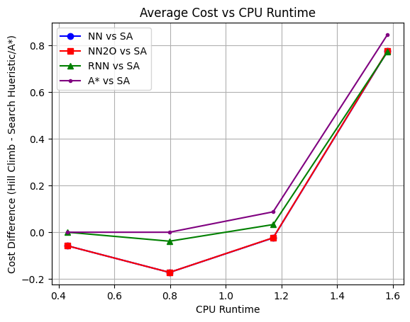

```python
plt.plot(SA_avg_cpu, SA_cost_diff['NN vs SA'], label='NN vs SA', marker='o', color='blue')
plt.plot(SA_avg_cpu, SA_cost_diff['NN2O vs SA'], label='NN2O vs SA', marker='s', color='red')
plt.plot(SA_avg_cpu, SA_cost_diff['RNN vs SA'], label='RNN vs SA', marker='^', color='green')
plt.plot(SA_avg_cpu, SA_cost_diff['A* vs SA'], label='A* vs SA', marker='.', color='purple')

# Add labels for x and y axes
plt.xlabel('CPU Runtime')
plt.ylabel('Cost Difference (Hill Climb - Search Hueristic/A*)')

# Add title to the plot
plt.title('Average Cost vs CPU Runtime')

# Add a legend to differentiate between the lines
plt.legend()

# Optionally, add gridlines for better readability
plt.grid(True)

# Show the plot
plt.show()
```

In the graph above we can see very similar results to that of Hill Climbing. For the smaller graphs (5, 10), the local search algorithms are able to find the optimal solution and therefore perform better than the search hueristics (and equivilent to A*) in terms of cost.

This graph also follows a similar trend as HC in terms of cost vs runtime. As the graphs get larger, the CPU runtime gets much longer and performance decreases.

I experimented a lot with different variables but the one that seemed to matter the most was the number of restarts. Without restarts, I coudnt get the average cost for size 15 under 5.2 and 6.2 for size 20. The more restarts the better it performed, however more restarts also comes with much more time to complete. I stuck somewhere in the middle with 8 restarts and messed with the other variables until I found a converging point.

Genetics Algorithm

```python
G_avg_cost = []
G_avg_cpu = []

# only using up to size 15 because it takes to long after that
for i, family in enumerate(families_f[:4], start=1):

    # initializing data collections
    G_data = {
        'Cost': [],
        'Real Runtime': [],
        'CPU Runtime': []
    }

    # Going through each matrix in this family (size)
    for m in family:

        #********************
        # Running Algorithm *
        #********************

        # Running Simulated Annealing
        G_start_real = time.time()
        G_start_CPU = time.process_time()
        G_tour, G_cost = Local_Search.gen(m, 100, 50, 0.6)
        G_end_real = time.time()
        G_end_CPU = time.process_time()

        #******************
        # Collecting Data *
        #******************

        # G
        G_data['Cost'].append(G_cost)
        G_data['Real Runtime'].append(G_end_real - G_start_real)
        G_data['CPU Runtime'].append(G_end_CPU - G_start_CPU)

    #*****************
    # Compiling Data *
    #*****************

    # G
    G_df = pd.DataFrame(G_data)
    G_averages = G_df.mean()
    G_min = G_df.min()
    G_max = G_df.max()

    G_avg_cost.append(G_averages['Cost'])
    G_avg_cpu.append(G_averages['CPU Runtime'])

    # Printing Results
    print('------------------------------')
    print('| AVERAGE/MIN/MAX For Size', i*5, '|')
    print('------------------------------')
    print('Averages: \n', G_averages, '\n')
    print('Minimums: \n', G_min, '\n')
    print('Maximums: \n', G_max, '\n')
```

```
------------------------------
| AVERAGE/MIN/MAX For Size 5 |
------------------------------
Averages:
 Cost            4.000000
Real Runtime    0.604392
CPU Runtime     0.604438
dtype: float64

Minimums:
 Cost            4.000000
Real Runtime    0.578726
CPU Runtime     0.578737
dtype: float64

Maximums:
 Cost            4.000000
Real Runtime    0.661323
CPU Runtime     0.661336
dtype: float64

------------------------------
| AVERAGE/MIN/MAX For Size 10 |
------------------------------
Averages:
 Cost            4.000000
Real Runtime    1.145976
CPU Runtime     1.146018
dtype: float64

Minimums:
 Cost            3.999999
Real Runtime    1.106775
CPU Runtime     1.106794
dtype: float64

Maximums:
 Cost            4.000001
Real Runtime    1.199522
CPU Runtime     1.199543
```

[output cut: 28 more lines]

```
Real Runtime    2.239856
CPU Runtime     2.239740
dtype: float64

Minimums:
 Cost            3.999997
Real Runtime    2.165596
CPU Runtime     2.165631
dtype: float64

Maximums:
 Cost            7.068726
Real Runtime    2.311317
CPU Runtime     2.311353
dtype: float64
```

Making Graphs

```python
G_cost_diff = {
    'NN vs G': [G_avg_cost[i] - cost for i, cost in enumerate(nn_avg['Cost'][:4])],
    'NN2O vs G': [G_avg_cost[i] - cost for i, cost in enumerate(nn2o_avg['Cost'][:4])],
    'RNN vs G': [G_avg_cost[i] - cost for i, cost in enumerate(rnn_avg['Cost'][:4])],
    'A* vs G': [G_avg_cost[i] - cost for i, cost in enumerate(A_avg_cost)] + [G_avg_cost[3] - 4.0]
}
```

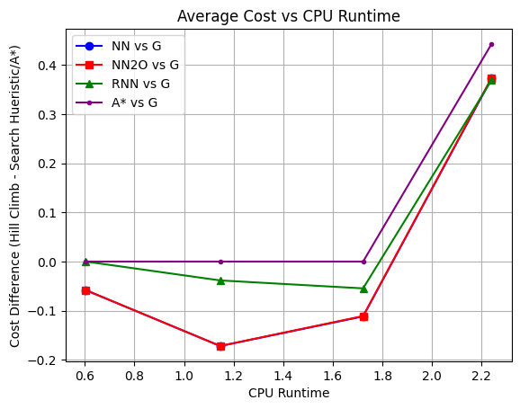

```python
plt.plot(G_avg_cpu, G_cost_diff['NN vs G'], label='NN vs G', marker='o', color='blue')
plt.plot(G_avg_cpu, G_cost_diff['NN2O vs G'], label='NN2O vs G', marker='s', color='red')
plt.plot(G_avg_cpu, G_cost_diff['RNN vs G'], label='RNN vs G', marker='^', color='green')
plt.plot(G_avg_cpu, G_cost_diff['A* vs G'], label='A* vs G', marker='.', color='purple')

# Add labels for x and y axes
plt.xlabel('CPU Runtime')
plt.ylabel('Cost Difference (Hill Climb - Search Hueristic/A*)')

# Add title to the plot
plt.title('Average Cost vs CPU Runtime')

# Add a legend to differentiate between the lines
plt.legend()

# Optionally, add gridlines for better readability
plt.grid(True)

# Show the plot
plt.show()
```

On the topic of generations, while experimenting I noticed that increasing the number of generations would help the larger graphs find the optimal solutions. This came with a trade off of much more time to compute.

All of these local search algorithms seem to follow the same trend; the bigger the graph --> the more nodes expanded --> the longer computation will take.